# Task 6.2 – Exploring Relationships (CWUR Dataset)

# 3. Scatterplots – Exploring Strong Correlations

Two strong relationships were further explored using scatterplots:

1. **Publications vs Citations**
   - The scatterplot shows a clear positive relationship: universities producing more publications also receive more citations.
   - This suggests that volume of research output is strongly linked to research impact and recognition.
2. **Quality of Faculty vs Influence**
   - There is a noticeable positive correlation between the quality of faculty and the university's influence.
   - This highlights that prestigious faculty members contribute significantly to the visibility and global standing of an institution.

Both scatterplots reinforce the importance of research excellence and faculty quality in driving institutional reputation.

# 3.1 Publications vs Score

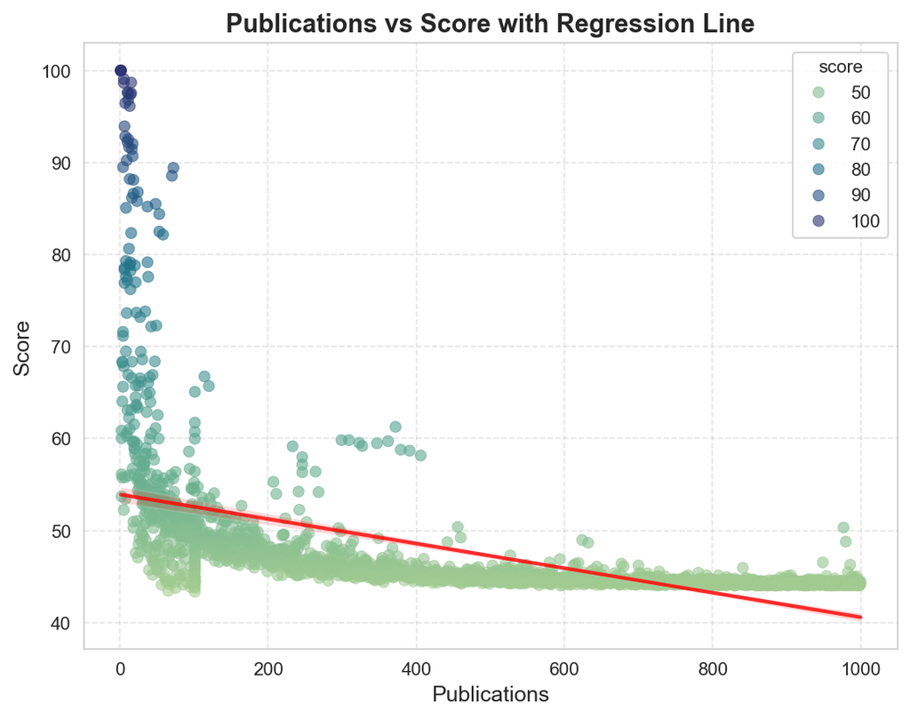

```python
plt.figure(figsize=(8,6), dpi=150)

sns.scatterplot(
    x="publications", y="score",
    hue="score",
    palette="crest",
    data=cwur_df,
    alpha=0.6,
    edgecolor=None
)

# Regression line
sns.regplot(
    x="publications", y="score",
    data=cwur_df,
    scatter=False,
    color="red",
    line_kws={"linewidth":2, "alpha":0.8}
)

plt.title("Publications vs Score with Regression Line", fontsize=14, fontweight="bold")
plt.xlabel("Publications", fontsize=12)
plt.ylabel("Score", fontsize=12)

# Grid
plt.grid(True, linestyle="--", alpha=0.5)

plt.show()
```

**Insight:**

The scatterplot with regression line reveals a **negative trend between publications and overall score**.  
While some universities achieve strong scores with modest publication output, those with very high publication counts tend to cluster at mid-to-lower score ranges.  
This suggests that **quality (impact, citations) is more critical than quantity of publications** in determining rankings.  
The regression line confirms that excessive publication volume does not guarantee higher institutional performance.

# 3.2 Publications vs Citations

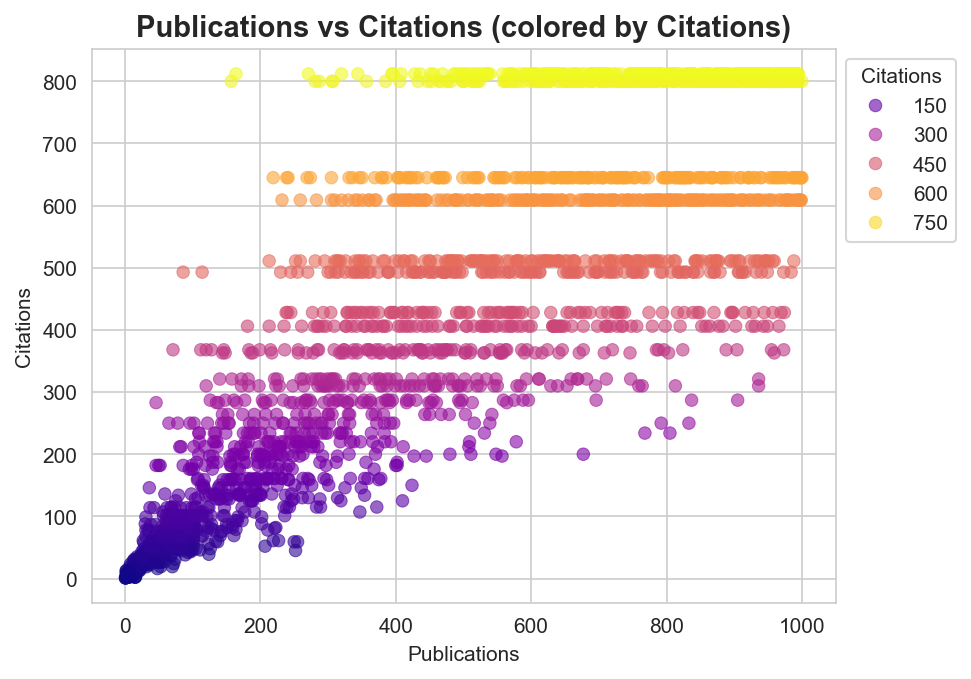

```python
plt.figure(dpi=150)
sns.scatterplot(
    x="publications",
    y="citations",
    data=cwur_df,
    hue="citations",
    palette="plasma",
    alpha=0.6,
    edgecolor=None
)
plt.title("Publications vs Citations (colored by Citations)", fontsize=14, fontweight="bold")
plt.xlabel("Publications")
plt.ylabel("Citations")
plt.legend(title="Citations", loc="upper left", bbox_to_anchor=(1,1))
plt.show()
```

**Insight:**

The scatterplot shows a positive relationship between publications and citations. Universities with more publications tend to accumulate higher citation counts, but the spread indicates variability: some institutions achieve high citations even with fewer publications, suggesting that research quality and impact can outweigh sheer output.

# 3.3 Quality of Faculty vs Influence

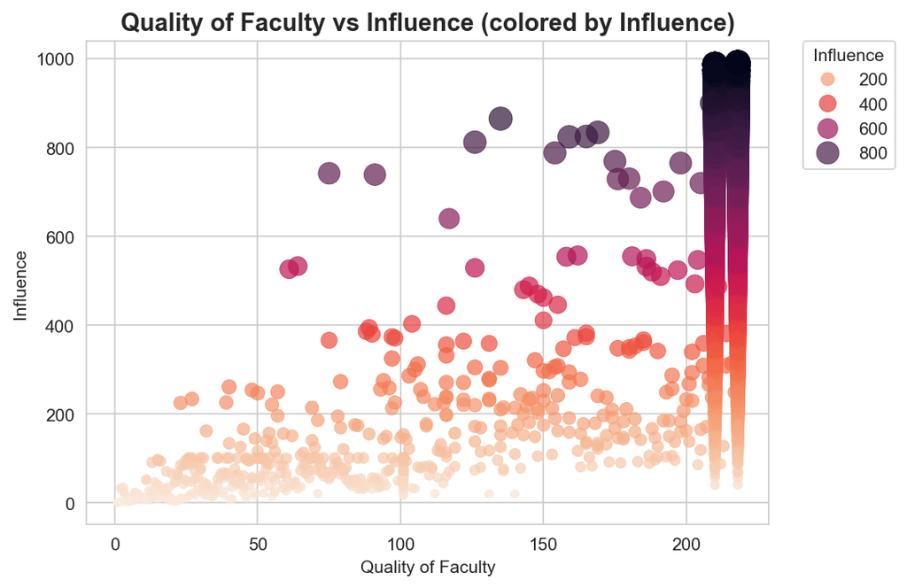

```python
plt.figure(figsize=(7,5), dpi=150)
sns.scatterplot(
    x="quality_of_faculty",
    y="influence",
    hue="influence",
    size="influence",
    sizes=(20, 200),
    palette="rocket_r",
    data=cwur_df,
    alpha=0.7,
    edgecolor=None
)

plt.title("Quality of Faculty vs Influence (colored by Influence)", fontsize=14, fontweight="bold")
plt.xlabel("Quality of Faculty")
plt.ylabel("Influence")
plt.legend(loc="best", title="Influence", bbox_to_anchor=(1.05, 1), borderaxespad=0.)
plt.show()
```

**Insight:**

The scatterplot indicates a moderate positive relationship between faculty quality and institutional influence. While universities with stronger faculty quality tend to achieve higher influence scores, the significant variability suggests that influence is not solely determined by faculty quality. Instead, external prestige factors—such as international collaborations, global reputation, and visibility—also play a key role. Interestingly, a small number of institutions demonstrate exceptionally high influence despite having only mid-range faculty quality, suggesting alternative pathways to global recognition.